# option price optimization

```python
import yfinance as yf
import pandas as pd
import time
from datetime import datetime
import matplotlib.pyplot as plt
import seaborn as sns
import numpy as np
```

**Function to download Tesla Data**

```python
def get_tesla_data(start_date, end_date):
    tesla = yf.Ticker("TSLA")
    stock_data = tesla.history(start=start_date, end=end_date)
    return stock_data
```

**Function to Calculate Historical Volatility**

```python
def calculate_historical_volatility(stock_data, window=30):
    stock_data['Daily_Return'] = stock_data['Close'].pct_change()
    stock_data['Historical_Volatility'] = (
        stock_data['Daily_Return'].rolling(window=window).std() * (252 ** 0.5)
    )
    return stock_data
```

**Function to get Tesla options chain**

```python
def get_options_data(ticker):
    stock = yf.Ticker(ticker)
    option_dates = stock.options
    all_options = []

    for date in option_dates:
        options = stock.option_chain(date)
        options_df = pd.concat([options.calls, options.puts])
        options_df['Expiration_Date'] = date
        all_options.append(options_df)

    return pd.concat(all_options)
```

**Function to download additional market factors (e.g., interest rates, stock price changes)**

```python
def get_market_factors(start_date, end_date):
    tesla = yf.Ticker("TSLA")
    stock_data = tesla.history(start=start_date, end=end_date)
    stock_data['Daily_Change'] = stock_data['Close'].diff()
    return stock_data[['Close', 'Daily_Change']]
```

```python
if __name__ == '__main__':
    start_date = '2007-01-01'
    end_date = datetime.today().strftime('%Y-%m-%d')

    print("Fetching Tesla stock data...")
    tesla_data = get_tesla_data(start_date, end_date)
    tesla_data = calculate_historical_volatility(tesla_data)
    print("Tesla stock data with historical volatility calculated.")

    print("Fetching Tesla options data...")
    tesla_options_data = get_options_data("TSLA")
    print(f"Fetched {len(tesla_options_data)} options data records.")

    print("Fetching additional market factors...")
    market_factors = get_market_factors(start_date, end_date)
    print("Market factors data collected.")

    tesla_data.to_csv("tesla_stock_data.csv", index=True)
    tesla_options_data.to_csv("tesla_options_data.csv", index=False)
    market_factors.to_csv("tesla_market_factors.csv", index=True)

    print("All data collected and saved.")
```

```
Fetching Tesla stock data...
```

```
Tesla stock data with historical volatility calculated.
Fetching Tesla options data...
Fetched 3850 options data records.
Fetching additional market factors...
Market factors data collected.
All data collected and saved.
```

```python
tesla_data.columns
```

```
Index(['Open', 'High', 'Low', 'Close', 'Volume', 'Dividends', 'Stock Splits',
       'Daily_Return', 'Historical_Volatility'],
      dtype='object')
```

```python
tesla_data.head()
```

| Date | Open | High | Low | Close | Volume | Dividends | Stock Splits | Daily_Return | Historical_Volatility |
| --- | --- | --- | --- | --- | --- | --- | --- | --- | --- |
| 2010-06-29 00:00:00-04:00 | 1.266667 | 1.666667 | 1.169333 | 1.592667 | 281494500 | 0.0 | 0.0 | NaN | NaN |
| 2010-06-30 00:00:00-04:00 | 1.719333 | 2.028000 | 1.553333 | 1.588667 | 257806500 | 0.0 | 0.0 | -0.002511 | NaN |
| 2010-07-01 00:00:00-04:00 | 1.666667 | 1.728000 | 1.351333 | 1.464000 | 123282000 | 0.0 | 0.0 | -0.078473 | NaN |
| 2010-07-02 00:00:00-04:00 | 1.533333 | 1.540000 | 1.247333 | 1.280000 | 77097000 | 0.0 | 0.0 | -0.125683 | NaN |
| 2010-07-06 00:00:00-04:00 | 1.333333 | 1.333333 | 1.055333 | 1.074000 | 103003500 | 0.0 | 0.0 | -0.160937 | NaN |

```python
tesla_options_data.columns
```

```
Index(['contractSymbol', 'lastTradeDate', 'strike', 'lastPrice', 'bid', 'ask',
       'change', 'percentChange', 'volume', 'openInterest',
       'impliedVolatility', 'inTheMoney', 'contractSize', 'currency',
       'Expiration_Date'],
      dtype='object')
```

```python
market_factors.head()
```

| Date | Close | Daily_Change |
| --- | --- | --- |
| 2010-06-29 00:00:00-04:00 | 1.592667 | NaN |
| 2010-06-30 00:00:00-04:00 | 1.588667 | -0.004000 |
| 2010-07-01 00:00:00-04:00 | 1.464000 | -0.124667 |
| 2010-07-02 00:00:00-04:00 | 1.280000 | -0.184000 |
| 2010-07-06 00:00:00-04:00 | 1.074000 | -0.206000 |

```python
tesla_options_data.head()
```

|  | contractSymbol | lastTradeDate | strike | lastPrice | bid | ask | change | percentChange | volume | openInterest | impliedVolatility | inTheMoney | contractSize | currency | Expiration_Date |
| --- | --- | --- | --- | --- | --- | --- | --- | --- | --- | --- | --- | --- | --- | --- | --- |
| 0 | TSLA241129C00075000 | 2024-11-26 16:59:31+00:00 | 75.0 | 267.70 | 256.25 | 259.50 | 0.000000 | 0.000000 | 1.0 | 10 | 11.015628 | True | REGULAR | USD | 2024-11-29 |
| 1 | TSLA241129C00080000 | 2024-10-24 13:36:18+00:00 | 80.0 | 170.00 | 271.20 | 274.05 | 0.000000 | 0.000000 | NaN | 1 | 20.656254 | True | REGULAR | USD | 2024-11-29 |
| 2 | TSLA241129C00085000 | 2024-11-13 15:12:50+00:00 | 85.0 | 248.20 | 246.25 | 249.05 | 0.000000 | 0.000000 | 3.0 | 2 | 9.558598 | True | REGULAR | USD | 2024-11-29 |
| 3 | TSLA241129C00090000 | 2024-11-18 15:20:38+00:00 | 90.0 | 255.90 | 241.40 | 244.40 | 0.000000 | 0.000000 | 1.0 | 2 | 5.375003 | True | REGULAR | USD | 2024-11-29 |
| 4 | TSLA241129C00095000 | 2024-11-27 19:30:10+00:00 | 95.0 | 238.27 | 236.25 | 239.05 | -4.199997 | -1.732172 | 1.0 | 2 | 8.810551 | True | REGULAR | USD | 2024-11-29 |

**Merging the data**

```python
tesla_data = pd.read_csv("tesla_stock_data.csv", index_col=0, parse_dates=True)
tesla_options_data = pd.read_csv("tesla_options_data.csv")
market_factors = pd.read_csv("tesla_market_factors.csv", index_col=0, parse_dates=True)
```

```python
combined_data = tesla_data.join(market_factors, how='inner', lsuffix='_tesla', rsuffix='_market')
```

```python
combined_data.columns
```

```
Index(['Open', 'High', 'Low', 'Close_tesla', 'Volume', 'Dividends',
       'Stock Splits', 'Daily_Return', 'Historical_Volatility', 'Close_market',
       'Daily_Change'],
      dtype='object')
```

```python
tesla_options_data.columns
```

```
Index(['contractSymbol', 'lastTradeDate', 'strike', 'lastPrice', 'bid', 'ask',
       'change', 'percentChange', 'volume', 'openInterest',
       'impliedVolatility', 'inTheMoney', 'contractSize', 'currency',
       'Expiration_Date'],
      dtype='object')
```

**Data cleaning**

**Checking for data types**

```python
combined_data.info()
```

```
<class 'pandas.core.frame.DataFrame'>
Index: 3630 entries, 2010-06-29 00:00:00-04:00 to 2024-11-27 00:00:00-05:00
Data columns (total 11 columns):
 #   Column                 Non-Null Count  Dtype
---  ------                 --------------  -----
 0   Open                   3630 non-null   float64
 1   High                   3630 non-null   float64
 2   Low                    3630 non-null   float64
 3   Close_tesla            3630 non-null   float64
 4   Volume                 3630 non-null   int64
 5   Dividends              3630 non-null   float64
 6   Stock Splits           3630 non-null   float64
 7   Daily_Return           3629 non-null   float64
 8   Historical_Volatility  3600 non-null   float64
 9   Close_market           3630 non-null   float64
 10  Daily_Change           3629 non-null   float64
dtypes: float64(10), int64(1)
memory usage: 340.3+ KB
```

```python
tesla_options_data.info()
```

```
<class 'pandas.core.frame.DataFrame'>
RangeIndex: 3850 entries, 0 to 3849
Data columns (total 15 columns):
 #   Column             Non-Null Count  Dtype
---  ------             --------------  -----
 0   contractSymbol     3850 non-null   object
 1   lastTradeDate      3850 non-null   object
 2   strike             3850 non-null   float64
 3   lastPrice          3850 non-null   float64
 4   bid                3850 non-null   float64
 5   ask                3850 non-null   float64
 6   change             3850 non-null   float64
 7   percentChange      3850 non-null   float64
 8   volume             3727 non-null   float64
 9   openInterest       3850 non-null   int64
 10  impliedVolatility  3850 non-null   float64
 11  inTheMoney         3850 non-null   bool
 12  contractSize       3850 non-null   object
 13  currency           3850 non-null   object
 14  Expiration_Date    3850 non-null   object
dtypes: bool(1), float64(8), int64(1), object(5)
memory usage: 425.0+ KB
```

**Check for missing values**

```python
combined_data.isnull().sum()
```

```
Open                      0
High                      0
Low                       0
Close_tesla               0
Volume                    0
Dividends                 0
Stock Splits              0
Daily_Return              1
Historical_Volatility    30
Close_market              0
Daily_Change              1
dtype: int64
```

```python
tesla_options_data.isnull().sum()
```

```
contractSymbol         0
lastTradeDate          0
strike                 0
lastPrice              0
bid                    0
ask                    0
change                 0
percentChange          0
volume               123
openInterest           0
impliedVolatility      0
inTheMoney             0
contractSize           0
currency               0
Expiration_Date        0
dtype: int64
```

```python
print(combined_data.shape)
print(tesla_options_data.shape)
```

```
(3630, 11)
(3850, 15)
```

*Handling missing values*

```python
combined_data_clean = combined_data.fillna(method='bfill')
tesla_options_data_clean = tesla_options_data.fillna(method='bfill')
```

```python
combined_data= combined_data_clean
tesla_options_data = tesla_options_data_clean
```

**Check for duplicates**

```python
print(combined_data.duplicated().sum())
print(tesla_options_data.duplicated().sum())
```

```
0
0
```

```python
tesla_options_data.columns
```

```
Index(['contractSymbol', 'lastTradeDate', 'strike', 'lastPrice', 'bid', 'ask',
       'change', 'percentChange', 'volume', 'openInterest',
       'impliedVolatility', 'inTheMoney', 'contractSize', 'currency',
       'Expiration_Date'],
      dtype='object')
```

```python
combined_data.columns
```

```
Index(['Open', 'High', 'Low', 'Close_tesla', 'Volume', 'Dividends',
       'Stock Splits', 'Daily_Return', 'Historical_Volatility', 'Close_market',
       'Daily_Change'],
      dtype='object')
```

**Converting to the right data type**

```python
tesla_options_data['lastTradeDate'] = pd.to_datetime(tesla_options_data['lastTradeDate'])
tesla_options_data['Expiration_Date'] = pd.to_datetime(tesla_options_data['Expiration_Date'])
```

```python
tesla_options_data.dtypes
```

```
contractSymbol                    object
lastTradeDate        datetime64[ns, UTC]
strike                           float64
lastPrice                        float64
bid                              float64
ask                              float64
change                           float64
percentChange                    float64
volume                           float64
openInterest                       int64
impliedVolatility                float64
inTheMoney                          bool
contractSize                      object
currency                          object
Expiration_Date           datetime64[ns]
dtype: object
```

```python
print("Combined Data Summary:")
print(combined_data.describe())

print("\nTesla Options Data Summary:")
print(tesla_options_data.describe())

print("\nMissing Values in Combined Data:")
print(combined_data.isnull().sum())

print("\nMissing Values in Tesla Options Data:")
print(tesla_options_data.isnull().sum())
```

```
Combined Data Summary:
              Open         High          Low  Close_tesla        Volume  \
count  3630.000000  3630.000000  3630.000000  3630.000000  3.630000e+03
mean     79.538537    81.277302    77.683911    79.517091  9.672648e+07
std     104.838872   107.162252   102.303228   104.758542  7.793420e+07
min       1.076000     1.108667     0.998667     1.053333  1.777500e+06
25%      11.993001    12.316167    11.703333    12.001833  4.867658e+07
50%      17.790668    18.066668    17.493334    17.822333  8.201895e+07
75%     175.295006   179.417496   172.507496   175.757496  1.224510e+08
max     411.470001   414.496674   405.666656   409.970001  9.140820e+08

       Dividends  Stock Splits  Daily_Return  Historical_Volatility  \
count     3630.0   3630.000000   3630.000000            3630.000000
mean         0.0      0.002204      0.002120               0.536818
std          0.0      0.096768      0.036109               0.196460
min          0.0      0.000000     -0.210628               0.183423
25%          0.0      0.000000     -0.016133               0.390868
50%          0.0      0.000000      0.001223               0.506403
75%          0.0      0.000000      0.019342               0.630190
max          0.0      5.000000      0.243951               1.393598

       Close_market  Daily_Change
count   3630.000000   3630.000000
mean      79.517091      0.091265
std      104.758542      5.031865
min        1.053333    -46.480011
25%       12.001833     -0.279666
50%       17.822333      0.009333
75%      175.757496      0.376334
max      409.970001     47.666656

Tesla Options Data Summary:
            strike    lastPrice          bid          ask       change  \
count  3850.000000  3850.000000  3850.000000  3850.000000  3850.000000
mean    327.978571    87.987127    87.554158    89.202086    -1.462982
min       5.000000     0.010000     0.000000     0.010000   -73.399994
25%     175.000000     3.300000     3.150000     3.350000    -2.787495
50%     310.000000    45.350000    44.375000    45.775000     0.000000
75%     460.000000   152.980000   152.487500   155.862500     0.000000
max     710.000000   385.200000   382.100000   389.600000   119.600006
```

[output cut: 38 more lines]

```
lastTradeDate        0
strike               0
lastPrice            0
bid                  0
ask                  0
change               0
percentChange        0
volume               0
openInterest         0
impliedVolatility    0
inTheMoney           0
contractSize         0
currency             0
Expiration_Date      0
dtype: int64
```

```python
combined_data.describe()
```

|  | Open | High | Low | Close_tesla | Volume | Dividends | Stock Splits | Daily_Return | Historical_Volatility | Close_market | Daily_Change |
| --- | --- | --- | --- | --- | --- | --- | --- | --- | --- | --- | --- |
| count | 3630.000000 | 3630.000000 | 3630.000000 | 3630.000000 | 3.630000e+03 | 3630.0 | 3630.000000 | 3630.000000 | 3630.000000 | 3630.000000 | 3630.000000 |
| mean | 79.538537 | 81.277302 | 77.683911 | 79.517091 | 9.672648e+07 | 0.0 | 0.002204 | 0.002120 | 0.536818 | 79.517091 | 0.091265 |
| std | 104.838872 | 107.162252 | 102.303228 | 104.758542 | 7.793420e+07 | 0.0 | 0.096768 | 0.036109 | 0.196460 | 104.758542 | 5.031865 |
| min | 1.076000 | 1.108667 | 0.998667 | 1.053333 | 1.777500e+06 | 0.0 | 0.000000 | -0.210628 | 0.183423 | 1.053333 | -46.480011 |
| 25% | 11.993001 | 12.316167 | 11.703333 | 12.001833 | 4.867658e+07 | 0.0 | 0.000000 | -0.016133 | 0.390868 | 12.001833 | -0.279666 |
| 50% | 17.790668 | 18.066668 | 17.493334 | 17.822333 | 8.201895e+07 | 0.0 | 0.000000 | 0.001223 | 0.506403 | 17.822333 | 0.009333 |
| 75% | 175.295006 | 179.417496 | 172.507496 | 175.757496 | 1.224510e+08 | 0.0 | 0.000000 | 0.019342 | 0.630190 | 175.757496 | 0.376334 |
| max | 411.470001 | 414.496674 | 405.666656 | 409.970001 | 9.140820e+08 | 0.0 | 5.000000 | 0.243951 | 1.393598 | 409.970001 | 47.666656 |

```python
tesla_options_data.describe()
```

|  | strike | lastPrice | bid | ask | change | percentChange | volume | openInterest | impliedVolatility | Expiration_Date |
| --- | --- | --- | --- | --- | --- | --- | --- | --- | --- | --- |
| count | 3850.000000 | 3850.000000 | 3850.000000 | 3850.000000 | 3850.000000 | 3850.000000 | 3850.000000 | 3850.000000 | 3850.000000 | 3850 |
| mean | 327.978571 | 87.987127 | 87.554158 | 89.202086 | -1.462982 | -7.206075 | 526.289610 | 1970.666753 | 0.874552 | 2025-06-27 23:49:31.636363776 |
| min | 5.000000 | 0.010000 | 0.000000 | 0.010000 | -73.399994 | -87.500000 | 1.000000 | 0.000000 | 0.000010 | 2024-11-29 00:00:00 |
| 25% | 175.000000 | 3.300000 | 3.150000 | 3.350000 | -2.787495 | -9.808588 | 2.000000 | 68.000000 | 0.526425 | 2024-12-20 00:00:00 |
| 50% | 310.000000 | 45.350000 | 44.375000 | 45.775000 | 0.000000 | 0.000000 | 9.000000 | 475.500000 | 0.620323 | 2025-03-21 00:00:00 |
| 75% | 460.000000 | 152.980000 | 152.487500 | 155.862500 | 0.000000 | 0.000000 | 71.000000 | 2013.750000 | 0.898805 | 2025-09-19 00:00:00 |
| max | 710.000000 | 385.200000 | 382.100000 | 389.600000 | 119.600006 | 300.000000 | 99287.000000 | 71641.000000 | 20.656254 | 2027-01-15 00:00:00 |
| std | 182.956952 | 99.981795 | 99.705543 | 101.230297 | 5.685291 | 17.271828 | 3920.984807 | 4269.841539 | 0.781734 | NaN |

**Data Visualization**

**Time Series PLots for Key Variables**

*Time series of Tesla stock closing prices over time*

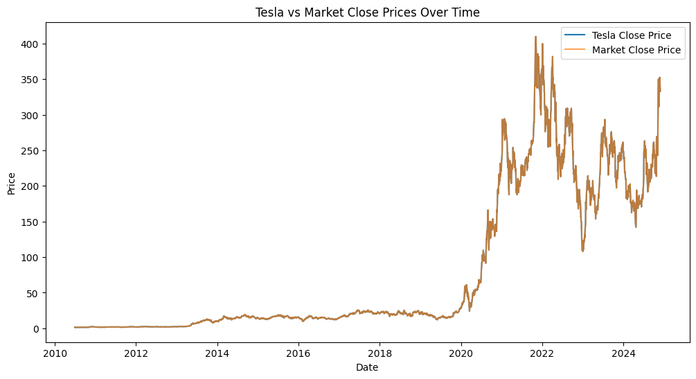

```python
plt.figure(figsize=(12, 6))
plt.plot(combined_data.index, combined_data['Close_tesla'], label="Tesla Close Price")
plt.plot(combined_data.index, combined_data['Close_market'], label="Market Close Price", alpha=0.7)
plt.title("Tesla vs Market Close Prices Over Time")
plt.xlabel("Date")
plt.ylabel("Price")
plt.legend()
plt.show()
```

*plotting Daily Return and Historical Volatility*

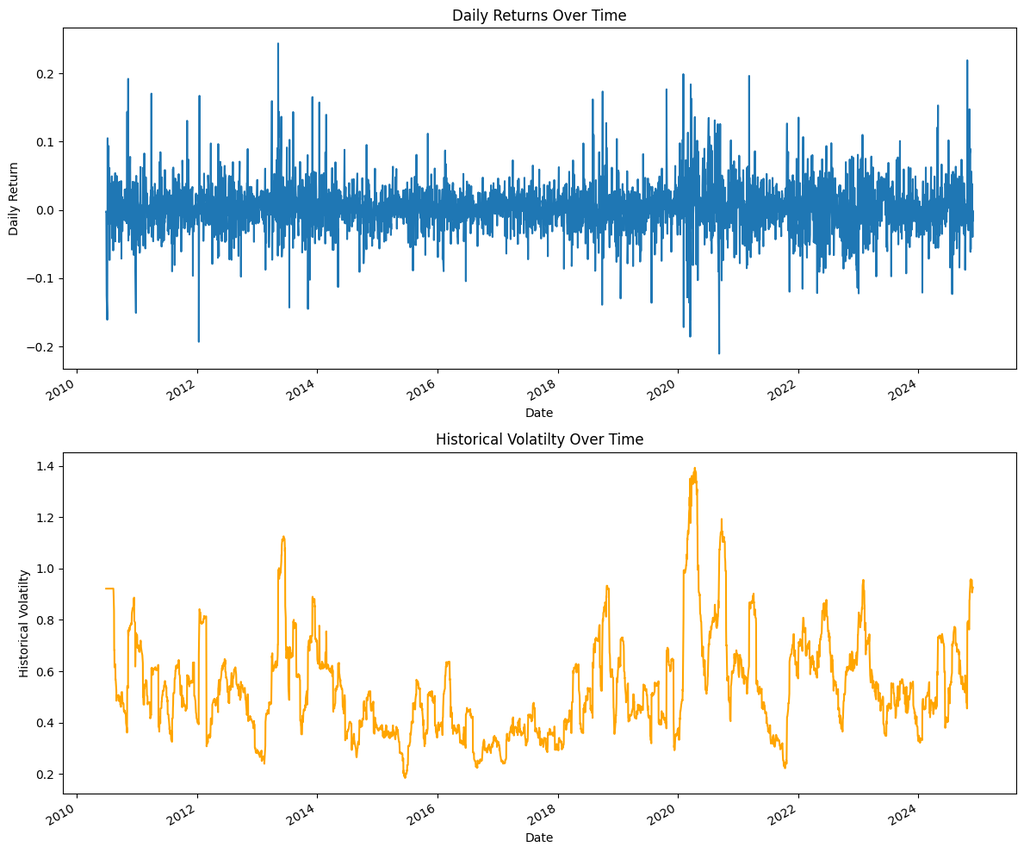

```python
fig, ax=plt.subplots(2, 1, figsize=(12, 10))
combined_data['Daily_Return'].plot(ax=ax[0], title="Daily Returns Over Time")
ax[0].set_ylabel("Daily Return")
combined_data['Historical_Volatility'].plot(ax=ax[1], title="Historical Volatilty Over Time", color='orange')
ax[1].set_ylabel("Historical Volatilty")
plt.tight_layout()
plt.show()
```

**Volatility Analysis**

*Correlation between volatily and returns*

```python
correlation = combined_data[['Daily_Return', 'Historical_Volatility', 'Daily_Change']].corr()
print("Correlation Matrix:\n", correlation)
```

```
Correlation Matrix:
                        Daily_Return  Historical_Volatility  Daily_Change
Daily_Return               1.000000               0.047977      0.641974
Historical_Volatility      0.047977               1.000000      0.010958
Daily_Change               0.641974               0.010958      1.000000
```

*Rolling window analysis for Historical Volatility (30day rolling mean)*

```python
combined_data['Volatility_Rolling'] = combined_data['Historical_Volatility'].rolling(window=30).mean()
```

*Plot rolling volatility*

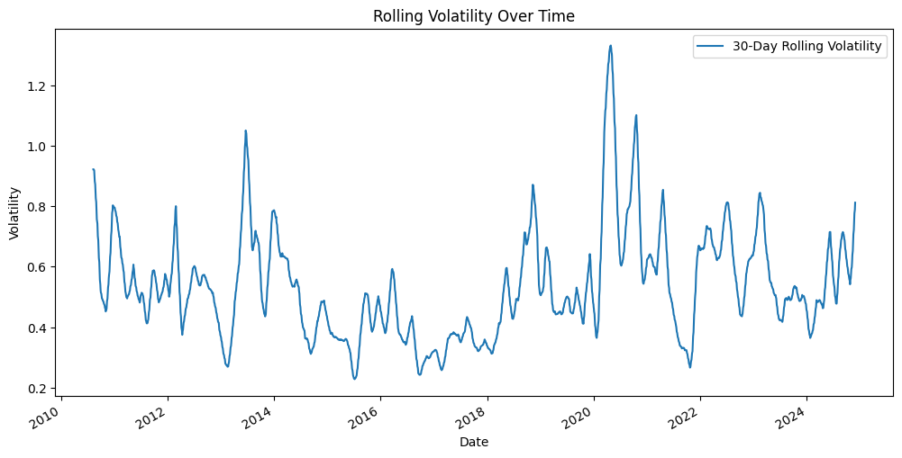

```python
plt.figure(figsize=(12, 6))
combined_data['Volatility_Rolling'].plot(label="30-Day Rolling Volatility")
plt.title("Rolling Volatility Over Time")
plt.xlabel("Date")
plt.ylabel("Volatility")
plt.legend()
plt.show()
```

**Distribution Analysis**

*Histogram and KDE plots for key numerical features*

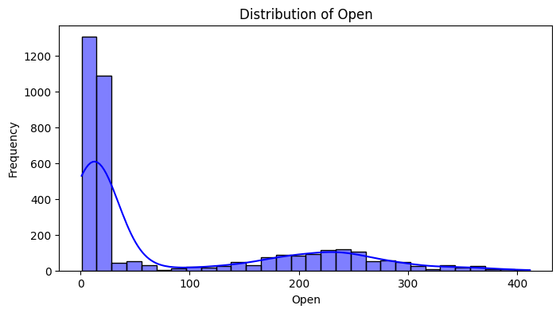

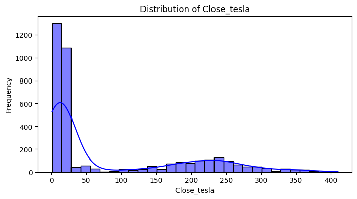

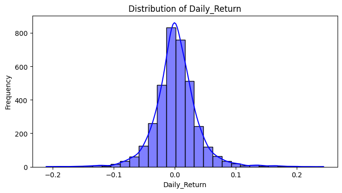

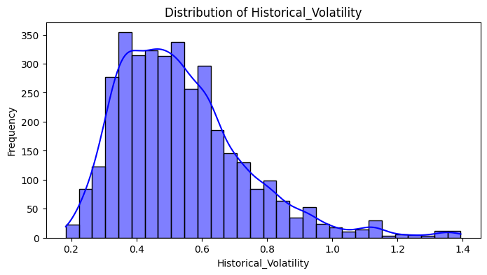

```python
features_to_plot = ['Open', 'Close_tesla', 'Daily_Return', 'Historical_Volatility']
for feature in features_to_plot:
    plt.figure(figsize=(8, 4))
    sns.histplot(combined_data[feature], kde=True, bins=30, color='blue')
    plt.title(f"Distribution of {feature}")
    plt.xlabel(feature)
    plt.ylabel("Frequency")
    plt.show()
```

**Relationship Analysis**

*Pairplot for realtionships between key columns*

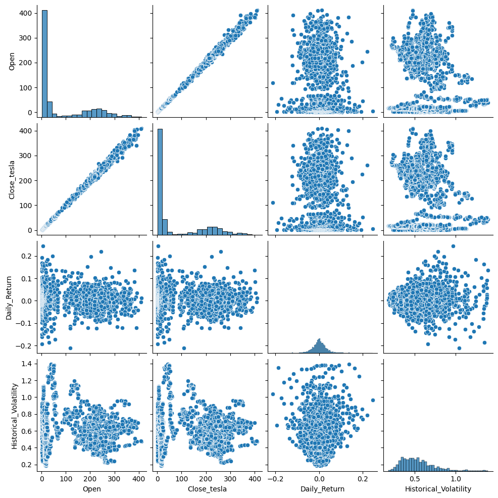

```python
sns.pairplot(combined_data[['Open', 'Close_tesla', 'Daily_Return', 'Historical_Volatility']])
plt.show()
```

*Heatmap of correlations*

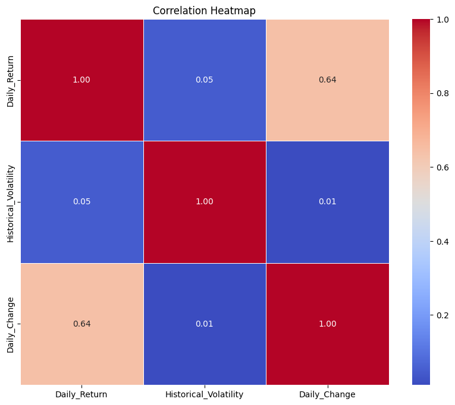

```python
plt.figure(figsize=(10, 8))
sns.heatmap(correlation, annot=True, cmap='coolwarm', fmt='.2f', linewidths=0.5)
plt.title("Correlation Heatmap")
plt.show()
```

**Tesla Options Data Exploration**

*Distribution of strike prices, implied volatility, and open interest*

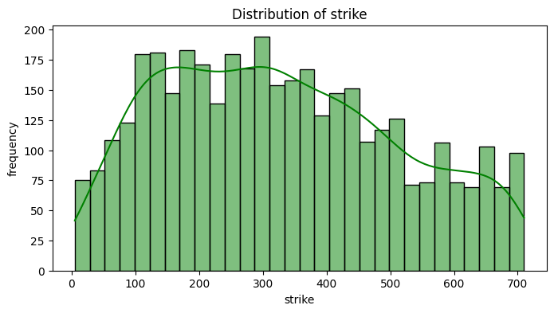

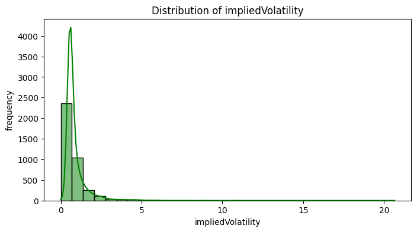

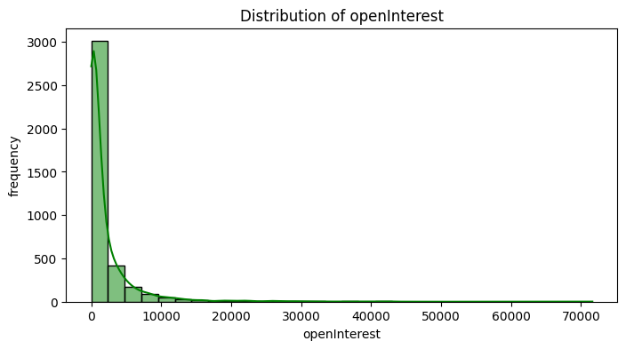

```python
features = ['strike', 'impliedVolatility', 'openInterest']
for feature in features:
    plt.figure(figsize=(8,4))
    sns.histplot(tesla_options_data[feature], kde=True, bins=30, color='green')
    plt.title(f"Distribution of {feature}")
    plt.xlabel(feature)
    plt.ylabel("frequency")
    plt.show()
```

**Bid-Ask Spread Analysis**

*Analyzing bid-ask spread*

```python
tesla_options_data['bid_ask_spread'] = tesla_options_data['ask'] - tesla_options_data['bid']
```

*Plot the distribution of the bid-ask spread*

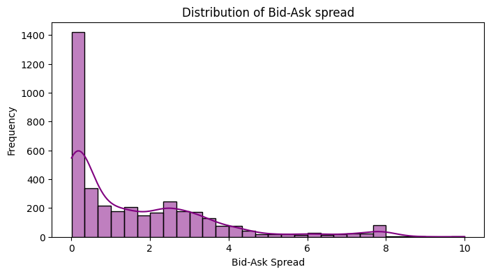

```python
plt.figure(figsize=(8, 4))
sns.histplot(tesla_options_data['bid_ask_spread'], kde=True, bins=30, color='purple')
plt.title("Distribution of Bid-Ask spread")
plt.xlabel("Bid-Ask Spread")
plt.ylabel("Frequency")
plt.show()
```

**Time-based Analysis**

*Aggregate volume and open interest by Expiration_Date*

```python
agg_data=tesla_options_data.groupby('Expiration_Date')[['volume', 'openInterest']].sum()
```

*Plot aggregated data*

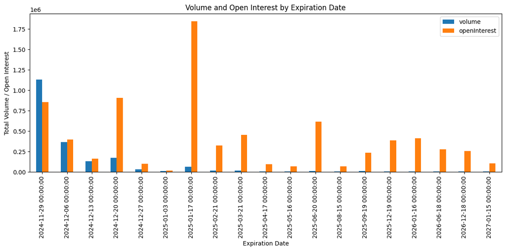

```python
agg_data.plot(kind='bar', figsize=(12, 6),title="Volume and Open Interest by Expiration Date")
plt.ylabel("Total Volume / Open Interest")
plt.xlabel("Expiration Date")
plt.tight_layout()
plt.show()
```

*Trend in implied volatility over time*

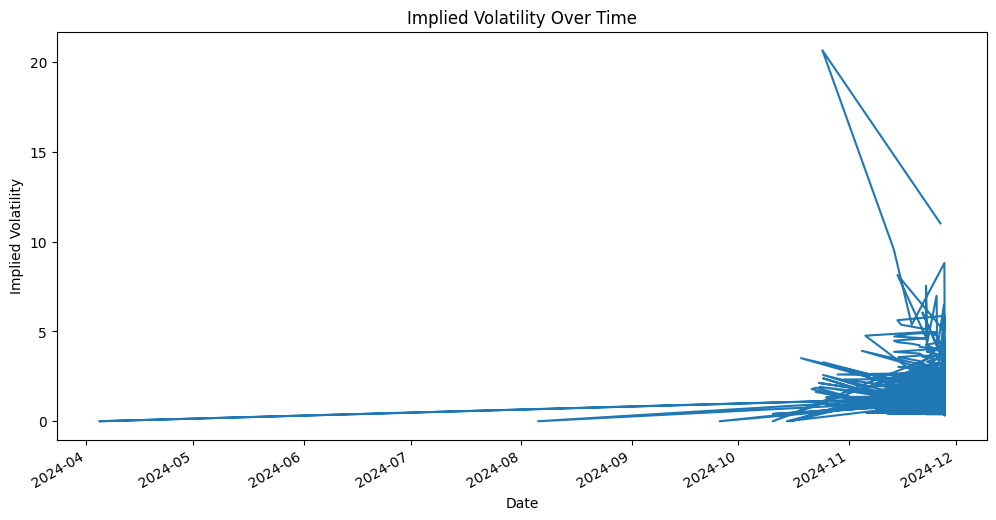

```python
tesla_options_data['lastTradeDate']=pd.to_datetime(tesla_options_data['lastTradeDate'])
tesla_options_data.set_index('lastTradeDate', inplace=True)
tesla_options_data['impliedVolatility'].plot(figsize=(12, 6), title="Implied Volatility Over Time")
plt.ylabel("Implied Volatility")
plt.xlabel("Date")
plt.show()
```

**Tesla Volume vs Market Close Price**

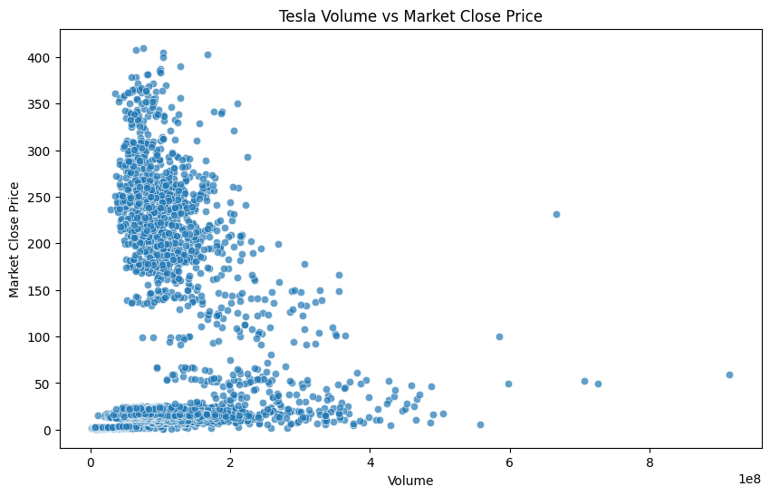

```python
plt.figure(figsize=(10, 6))
sns.scatterplot(x=combined_data['Volume'], y=combined_data['Close_market'], alpha=0.7)
plt.title("Tesla Volume vs Market Close Price")
plt.xlabel('Volume')
plt.ylabel('Market Close Price')
plt.show()
```

**Moving Average of Tesla Close Price**

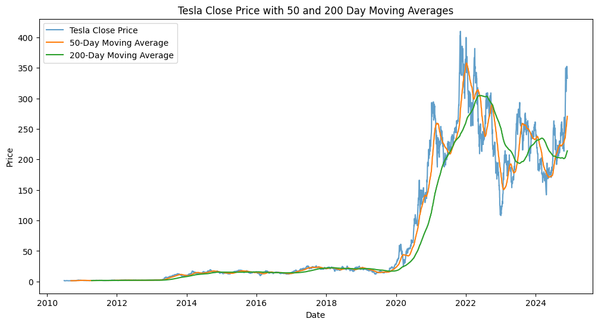

```python
combined_data['MA_50'] = combined_data['Close_tesla'].rolling(window=50).mean()
combined_data['MA_200'] = combined_data['Close_tesla'].rolling(window=200).mean()

plt.figure(figsize=(12, 6))
plt.plot(combined_data['Close_tesla'], label='Tesla Close Price', alpha=0.7)
plt.plot(combined_data['MA_50'], label='50-Day Moving Average')
plt.plot(combined_data['MA_200'], label='200-Day Moving Average')
plt.title("Tesla Close Price with 50 and 200 Day Moving Averages")
plt.xlabel('Date')
plt.ylabel('Price')
plt.legend()
plt.show()
```

**Implied Volatility by Strike Price**

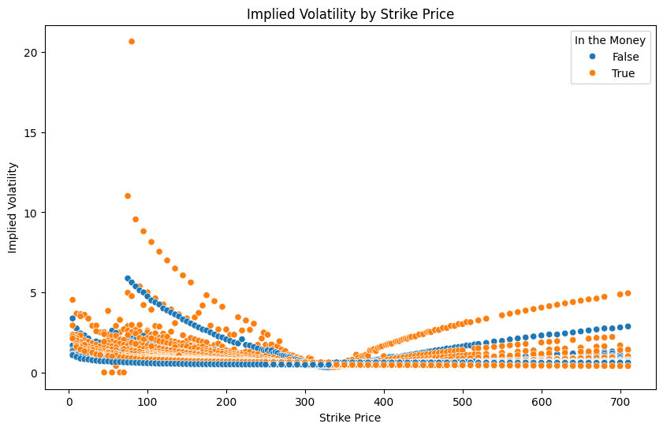

```python
plt.figure(figsize=(10, 6))
sns.scatterplot(x=tesla_options_data['strike'], y=tesla_options_data['impliedVolatility'],hue=tesla_options_data['inTheMoney'])
plt.title('Implied Volatility by Strike Price')
plt.xlabel('Strike Price')
plt.ylabel('Implied Volatility')
plt.legend(title='In the Money')
plt.show()
```

**Tesla Daily Return vs. Market Daily Change**

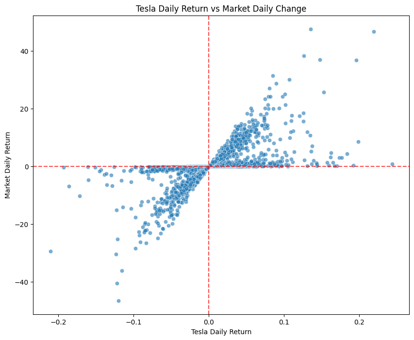

```python
plt.figure(figsize=(10, 8))
sns.scatterplot(x=combined_data['Daily_Return'], y=combined_data['Daily_Change'], alpha=0.6)
plt.title("Tesla Daily Return vs Market Daily Change")
plt.xlabel("Tesla Daily Return")
plt.ylabel("Market Daily Return")
plt.axhline(0, linestyle='--', color='red', alpha=0.7)
plt.axvline(0, linestyle='--', color='red', alpha=0.7)
plt.show()
```

**Tesla Historical Volatility Over Different Periods**

*Short-term and long-term rolling volatility*

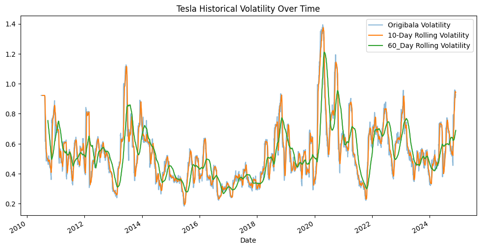

```python
combined_data['Volatility_10']= combined_data['Historical_Volatility'].rolling(window=10).mean()
combined_data['Volatility_60']= combined_data['Historical_Volatility'].rolling(window=60).mean()


plt.figure(figsize=(12, 6))
combined_data['Historical_Volatility'].plot(label="Origibala Volatility", alpha=0.5)
combined_data['Volatility_10'].plot(label="10-Day Rolling Volatility")
combined_data['Volatility_60'].plot(label="60_Day Rolling Volatility")
plt.title("Tesla Historical Volatility Over Time")
plt.xlabel("Date")
plt.legend()
plt.show()
```

**Relationship Between Bid-Ask Spread and Open Interest**

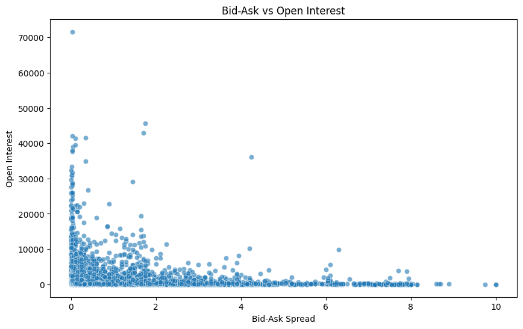

```python
plt.figure(figsize=(10, 6))
sns.scatterplot(x=tesla_options_data['bid_ask_spread'], y=tesla_options_data['openInterest'], alpha=0.6)
plt.title("Bid-Ask vs Open Interest")
plt.xlabel("Bid-Ask Spread")
plt.ylabel("Open Interest")
plt.show()
```

**Volume Distribution Over Time**

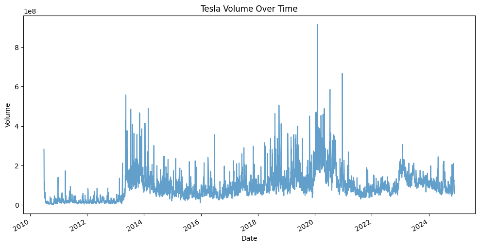

```python
plt.figure(figsize=(12, 6))
combined_data['Volume'].plot(kind='line', alpha=0.7)
plt.title("Tesla Volume Over Time")
plt.xlabel("Date")
plt.ylabel("Volume")
plt.show()
```

**Daily Change Box Plot**

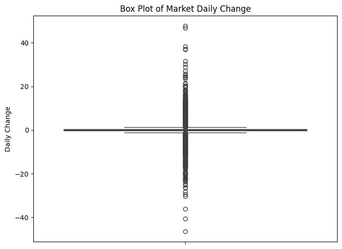

```python
plt.figure(figsize=(8, 6))
sns.boxplot(y=combined_data['Daily_Change'])
plt.title("Box Plot of Market Daily Change")
plt.ylabel("Daily Change")
plt.show()
```

**Correlation Heatmap with More Features**

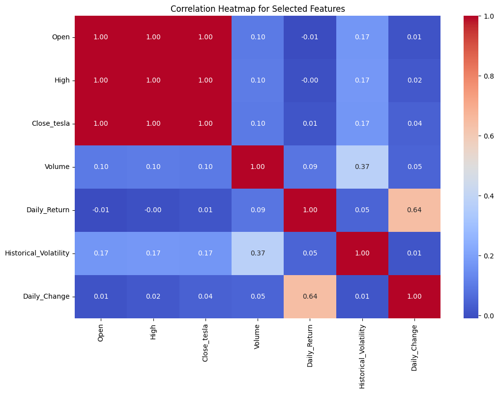

```python
selected_features =['Open', 'High', 'Close_tesla', 'Volume', 'Daily_Return', 'Historical_Volatility', 'Daily_Change']
plt.figure(figsize=(12, 8))
sns.heatmap(combined_data[selected_features].corr(), annot=True, cmap='coolwarm', fmt=".2f")
plt.title("Correlation Heatmap for Selected Features")
plt.show()
```

**Expiration Date vs. Volume**

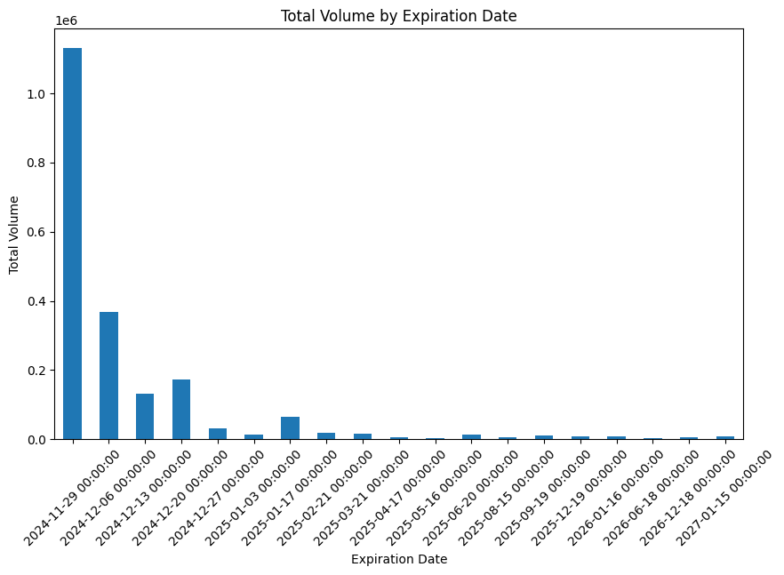

```python
plt.figure(figsize=(10, 6))
tesla_options_data.groupby('Expiration_Date')['volume'].sum().plot(kind='bar')
plt.title("Total Volume by Expiration Date")
plt.xlabel("Expiration Date")
plt.ylabel("Total Volume")
plt.xticks(rotation=45)
plt.show()
```

**Strike Price Histogram**

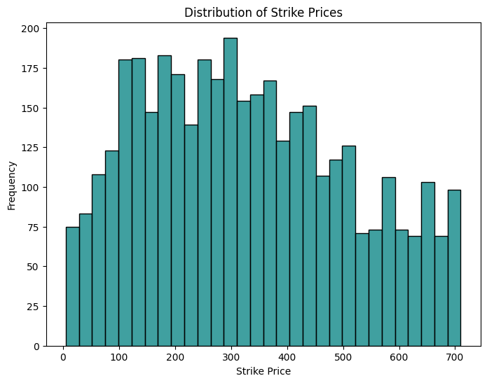

```python
plt.figure(figsize=(8, 6))
sns.histplot(tesla_options_data['strike'], bins=30, kde=False, color="teal")
plt.title("Distribution of Strike Prices")
plt.xlabel("Strike Price")
plt.ylabel("Frequency")
plt.show()
```

**Cumulative Returns Over Time**

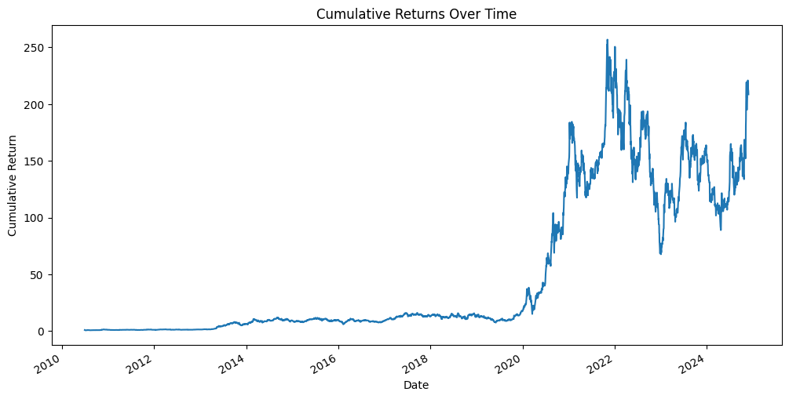

```python
combined_data['Cumulative_Return'] = (1+combined_data['Daily_Return']).cumprod()

plt.figure(figsize=(12, 6))
combined_data['Cumulative_Return'].plot()
plt.title("Cumulative Returns Over Time")
plt.xlabel("Date")
plt.ylabel("Cumulative Return")
plt.show()
```

**Volume vs. Tesla Close Price**

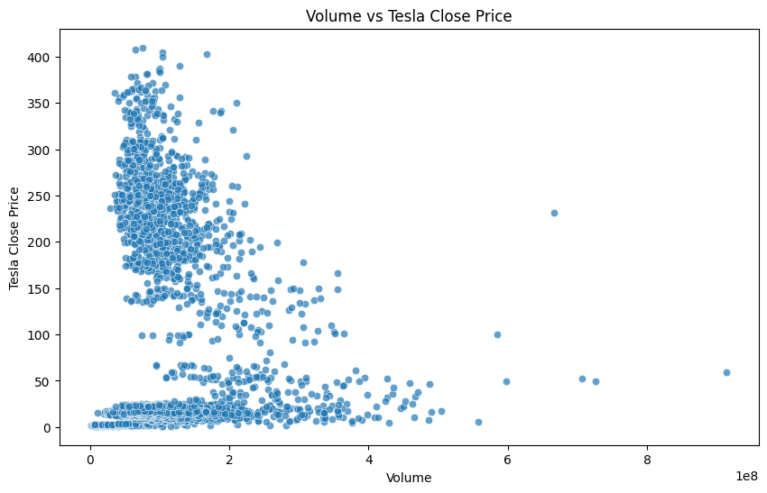

```python
plt.figure(figsize=(10, 6))
sns.scatterplot(x=combined_data['Volume'], y=combined_data['Close_tesla'], alpha=0.7)
plt.title("Volume vs Tesla Close Price")
plt.xlabel("Volume")
plt.ylabel("Tesla Close Price")
plt.show()
```

**Volume vs. Implied Volatility**

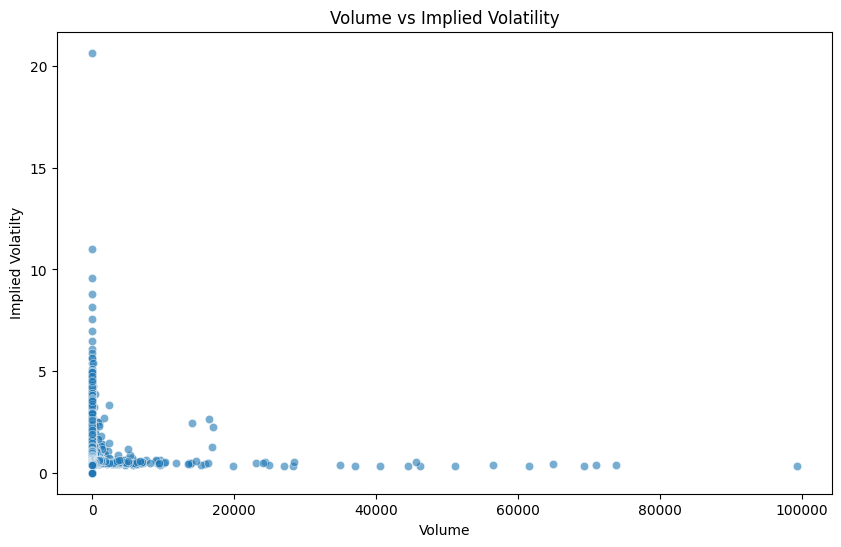

```python
plt.figure(figsize=(10, 6))
sns.scatterplot(x=tesla_options_data['volume'], y=tesla_options_data['impliedVolatility'],alpha=0.6)
plt.title("Volume vs Implied Volatility")
plt.xlabel("Volume")
plt.ylabel("Implied Volatilty")
plt.show()
```

**Market Close Price Moving Average**

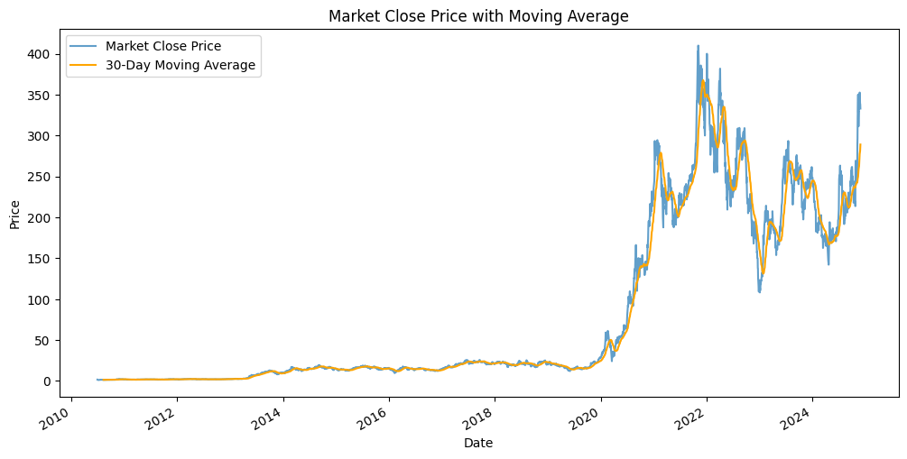

```python
combined_data['Market_MA_30'] = combined_data['Close_market'].rolling(window=30).mean()

plt.figure(figsize=(12, 6))
combined_data['Close_market'].plot(label="Market Close Price", alpha=0.7)
combined_data['Market_MA_30'].plot(label="30-Day Moving Average", color='orange')
plt.title("Market Close Price with Moving Average")
plt.xlabel("Date")
plt.ylabel("Price")
plt.legend()
plt.show()
```

**Machine Learning**

**Data Preprocessing**

**Define the Target Variable**

*Define the price movement as the target variable*

```python
tesla_options_data['price_movement'] = (tesla_options_data['lastPrice'].diff().fillna(0) > 0).astype(int)

tesla_options_data.dropna(subset=['price_movement'], inplace=True)
```

```python
tesla_options_data.head()
```

| lastTradeDate | contractSymbol | strike | lastPrice | bid | ask | change | percentChange | volume | openInterest | impliedVolatility | inTheMoney | contractSize | currency | Expiration_Date | bid_ask_spread | price_movement |
| --- | --- | --- | --- | --- | --- | --- | --- | --- | --- | --- | --- | --- | --- | --- | --- | --- |
| 2024-11-26 16:59:31+00:00 | TSLA241129C00075000 | 75.0 | 267.70 | 256.25 | 259.50 | 0.000000 | 0.000000 | 1.0 | 10 | 11.015628 | True | REGULAR | USD | 2024-11-29 | 3.25 | 0 |
| 2024-10-24 13:36:18+00:00 | TSLA241129C00080000 | 80.0 | 170.00 | 271.20 | 274.05 | 0.000000 | 0.000000 | 3.0 | 1 | 20.656254 | True | REGULAR | USD | 2024-11-29 | 2.85 | 0 |
| 2024-11-13 15:12:50+00:00 | TSLA241129C00085000 | 85.0 | 248.20 | 246.25 | 249.05 | 0.000000 | 0.000000 | 3.0 | 2 | 9.558598 | True | REGULAR | USD | 2024-11-29 | 2.80 | 1 |
| 2024-11-18 15:20:38+00:00 | TSLA241129C00090000 | 90.0 | 255.90 | 241.40 | 244.40 | 0.000000 | 0.000000 | 1.0 | 2 | 5.375003 | True | REGULAR | USD | 2024-11-29 | 3.00 | 1 |
| 2024-11-27 19:30:10+00:00 | TSLA241129C00095000 | 95.0 | 238.27 | 236.25 | 239.05 | -4.199997 | -1.732172 | 1.0 | 2 | 8.810551 | True | REGULAR | USD | 2024-11-29 | 2.80 | 0 |

```python
tesla_options_data.shape
```

```
(3850, 16)
```

```python
tesla_options_data['inTheMoney'] = tesla_options_data['inTheMoney'].apply(lambda x: 1 if x else 0)

print(tesla_options_data['inTheMoney'].value_counts())
print(tesla_options_data['contractSize'].value_counts())
```

```
inTheMoney
0    1959
1    1891
Name: count, dtype: int64
contractSize
REGULAR    3850
Name: count, dtype: int64
```

**select features**

```python
features = ['strike','bid', 'ask', 'volume', 'openInterest', 'impliedVolatility', 'inTheMoney']

X = tesla_options_data[features]
y= tesla_options_data['price_movement']
```

**Train-Test Split**

```python
import sklearn
from sklearn.model_selection import train_test_split

X_train, X_test, y_train, y_test = train_test_split(X, y, test_size=0.2, random_state=42)

print("Train-Test Split Complete:")
print('X_train shape:', X_train.shape)
print('X_test shape', X_test.shape)
print('y_train shape', y_train.shape)
print('y_test shape', y_test.shape)
```

```
Train-Test Split Complete:
X_train shape: (3080, 7)
X_test shape (770, 7)
y_train shape (3080,)
y_test shape (770,)
```

```python
import scipy
import sklearn
print(scipy.__version__)
print(sklearn.__version__)
```

```
1.14.1
1.5.2
```

**Feature Scaling**

```python
from sklearn.preprocessing import StandardScaler

scaler = StandardScaler()
X_train_scaled = scaler.fit_transform(X_train)
X_test_scaled = scaler.transform(X_test)
```

**Model Training and Validation**

```python
from sklearn.ensemble import RandomForestClassifier
from sklearn.metrics import accuracy_score, classification_report, confusion_matrix
```

**Initialize and train the model**

```python
rf_model = RandomForestClassifier(
    n_estimators=100,
    max_depth=10,
    random_state=42,
    class_weight='balanced'
)

rf_model.fit(X_train, y_train)
```

```
RandomForestClassifier(class_weight='balanced', max_depth=10, random_state=42)
```

```python
y_pred = rf_model.predict(X_test)
```

```python
y_pred_proba = rf_model.predict_proba(X_test)
```

**Model Evaluation**

```python
accuracy = accuracy_score(y_test, y_pred)
print(f'Accuracy: {accuracy:.2f}')

print('Classiication Report:\n', classification_report(y_test, y_pred))

print("Confusion Matrix:\n", confusion_matrix(y_test, y_pred))
```

```
Accuracy: 0.85
Classiication Report:
               precision    recall  f1-score   support

           0       0.86      0.88      0.87       424
           1       0.85      0.82      0.83       346

    accuracy                           0.85       770
   macro avg       0.85      0.85      0.85       770
weighted avg       0.85      0.85      0.85       770

Confusion Matrix:
 [[372  52]
 [ 62 284]]
```

**Feature Importance**

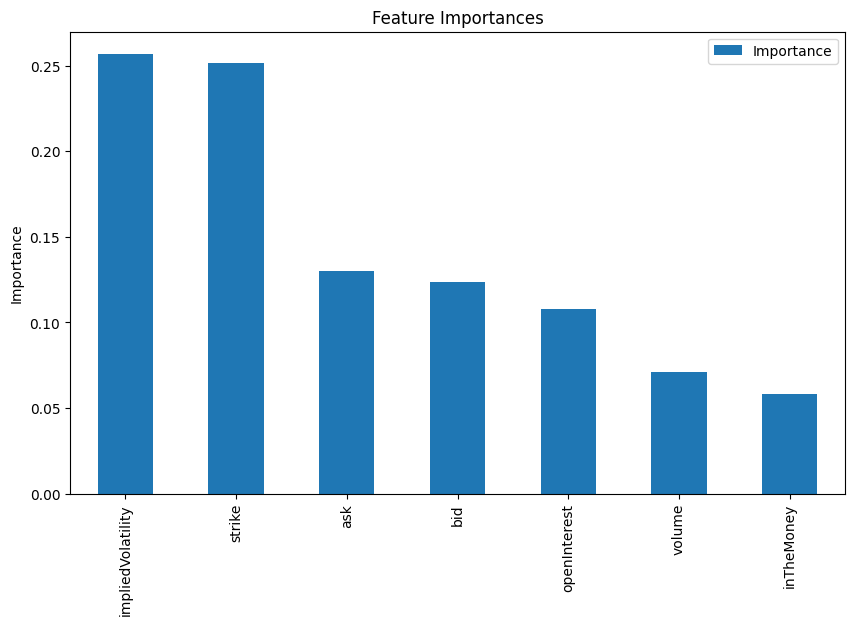

```python
feature_importances = pd.DataFrame(
    rf_model.feature_importances_,
    index=features,
    columns=['Importance']
).sort_values(by='Importance', ascending=False)

feature_importances.plot(kind='bar', figsize=(10, 6), title='Feature Importances')
plt.ylabel('Importance')
plt.show()
```

**Hyperparametric Tuning**

```python
from sklearn.model_selection import GridSearchCV
```

*Define parametergrid*

```python
param_grid = {
    'n_estimators':[100, 200, 300],
    'max_depth': [10, 20, None],
    'min_samples_split':[2, 5, 10],
    'min_samples_leaf':[1, 2, 4],
}
```

*Initialize GridSearchCV*

```python
grid_search = GridSearchCV(
    estimator=RandomForestClassifier(random_state=42, class_weight="balanced"),
    param_grid=param_grid,
    cv=3,
    scoring="accuracy",
    n_jobs=-1
)
```

*Fit GridSearchCV*

```python
grid_search.fit(X_train, y_train)
```

```
GridSearchCV(cv=3,
             estimator=RandomForestClassifier(class_weight='balanced',
                                              random_state=42),
             n_jobs=-1,
             param_grid={'max_depth': [10, 20, None],
                         'min_samples_leaf': [1, 2, 4],
                         'min_samples_split': [2, 5, 10],
                         'n_estimators': [100, 200, 300]},
             scoring='accuracy')
```

*Best parameters*

```python
print("Best Parameters:", grid_search.best_params_)
```

```
Best Parameters: {'max_depth': 10, 'min_samples_leaf': 1, 'min_samples_split': 10, 'n_estimators': 100}
```

*Update model with best parameters*

```python
rf_model =grid_search.best_estimator_
```

**Cross_Validation for Robust Evaluation**

```python
from sklearn.model_selection import cross_val_score
```

*Perform 5-fold cross-validation*

```python
cv_scores = cross_val_score(rf_model, X_train, y_train, cv=5, scoring='accuracy')
```

*Display the mean and standard deviation of cross-validation scores*

```python
print(f"Cross-Validation Accuracy:{cv_scores.mean():.4f} ± {cv_scores.std():.4f}")
```

```
Cross-Validation Accuracy:0.8370 ± 0.0124
```

**Learning Curve Analysis**

```python
from sklearn.model_selection import learning_curve
```